# Instacart Exploratory Analysis

Laia Esquerrà

```r
source("readDataToMemory.R")
```

```
Re-using existing Spark connection to local
```

```r
readInstacart()
library(DBI)
library(ggplot2)
library(ggthemes)
src_tbls(sc)
```

```
[1] "order_products__prior_tbl" "order_products__train_tbl" "orders_tbl"                "products_tbl"
```

### Order products

`order_products__*.csv`

These files specify which products were purchased in each order.

```r
dbGetQuery(sc, "SELECT * FROM order_products__prior_tbl LIMIT 10")
```

| order_id | product_id | add_to_cart_order | reordered |
| --- | --- | --- | --- |
| 2 | 33120 | 1 | 1 |
| 2 | 28985 | 2 | 1 |
| 2 | 9327 | 3 | 0 |
| 2 | 45918 | 4 | 1 |
| 2 | 30035 | 5 | 0 |
| 2 | 17794 | 6 | 1 |
| 2 | 40141 | 7 | 1 |
| 2 | 1819 | 8 | 1 |
| 2 | 43668 | 9 | 0 |
| 3 | 33754 | 1 | 1 |

## orders

`orders.csv`

This file tells to which set (prior, train, test) an order belongs.

```r
orders_prev <- dbGetQuery(sc, "SELECT * FROM orders_tbl LIMIT 100")
orders_prev
```

| order_id | user_id | eval_set | order_number | order_dow | order_hour_of_day | days_since_prior_order |
| --- | --- | --- | --- | --- | --- | --- |
| 2539329 | 1 | prior | 1 | 2 | 8 | NaN |
| 2398795 | 1 | prior | 2 | 3 | 7 | 15 |
| 473747 | 1 | prior | 3 | 3 | 12 | 21 |
| 2254736 | 1 | prior | 4 | 4 | 7 | 29 |
| 431534 | 1 | prior | 5 | 4 | 15 | 28 |
| 3367565 | 1 | prior | 6 | 2 | 7 | 19 |
| 550135 | 1 | prior | 7 | 1 | 9 | 20 |
| 3108588 | 1 | prior | 8 | 1 | 14 | 14 |
| 2295261 | 1 | prior | 9 | 1 | 16 | 0 |
| 2550362 | 1 | prior | 10 | 4 | 8 | 30 |

[output cut: 90 more lines]

```r
dbGetQuery(
  sc,
  "
SELECT COUNT(DISTINCT product_id) AS products
FROM order_products__prior_tbl
  "
  )
```

| products |
| --- |
| 49677 |

```r
products_popularity_txt <- "
SELECT product_id
,   COUNT(1) AS n_orders
FROM order_products__prior_tbl
GROUP BY product_id
ORDER BY n_orders DESC
LIMIT 50
"
products_popularity <-
  dbGetQuery(sc, products_popularity_txt)
products_popularity
```

| product_id | n_orders |
| --- | --- |
| 24852 | 472565 |
| 13176 | 379450 |
| 21137 | 264683 |
| 21903 | 241921 |
| 47209 | 213584 |
| 47766 | 176815 |
| 47626 | 152657 |
| 16797 | 142951 |
| 26209 | 140627 |
| 27845 | 137905 |

[output cut: 40 more lines]

## Products

`products.csv`

```r
dbGetQuery(sc, "SELECT * FROM products_tbl LIMIT 20")
```

| product_id | product_name | aisle_id | department_id |
| --- | --- | --- | --- |
| 1 | Chocolate Sandwich Cookies | 61 | 19 |
| 2 | All-Seasons Salt | 104 | 13 |
| 3 | Robust Golden Unsweetened Oolong Tea | 94 | 7 |
| 4 | Smart Ones Classic Favorites Mini Rigatoni With Vodka Cream Sauce | 38 | 1 |
| 5 | Green Chile Anytime Sauce | 5 | 13 |
| 6 | Dry Nose Oil | 11 | 11 |
| 7 | Pure Coconut Water With Orange | 98 | 7 |
| 8 | Cut Russet Potatoes Steam N' Mash | 116 | 1 |
| 9 | Light Strawberry Blueberry Yogurt | 120 | 16 |
| 10 | Sparkling Orange Juice & Prickly Pear Beverage | 115 | 7 |

[output cut: 10 more lines]

## Joins

```r
products_popularity_txt <- "
SELECT op.product_id
,   n_orders
,   product_name
FROM (
    SELECT product_id
    ,   COUNT(1) AS n_orders
    FROM order_products__prior_tbl
    GROUP BY product_id
    ORDER BY n_orders DESC
    LIMIT 30) op
LEFT JOIN (
    SELECT product_id
    ,   product_name
    FROM products_tbl) p
ON op.product_id = p.product_id
"
products_popularity <-
  dbGetQuery(sc, products_popularity_txt)
products_popularity
```

| product_id | n_orders | product_name |
| --- | --- | --- |
| 24852 | 472565 | Banana |
| 13176 | 379450 | Bag of Organic Bananas |
| 21137 | 264683 | Organic Strawberries |
| 21903 | 241921 | Organic Baby Spinach |
| 47209 | 213584 | Organic Hass Avocado |
| 47766 | 176815 | Organic Avocado |
| 47626 | 152657 | Large Lemon |
| 16797 | 142951 | Strawberries |
| 26209 | 140627 | Limes |
| 27845 | 137905 | Organic Whole Milk |

[output cut: 20 more lines]

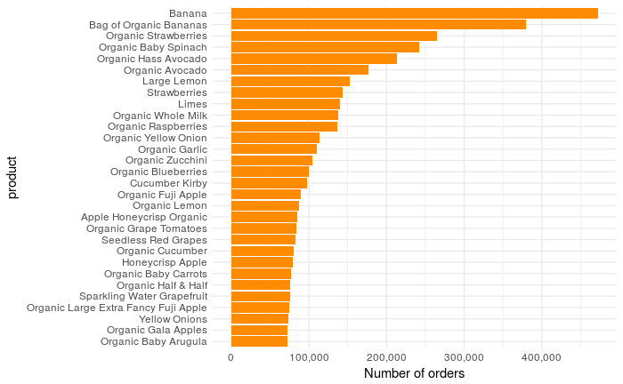

```r
products_popularity %>%
  ggplot(
    aes(reorder(product_name, n_orders, function(x) x),
        n_orders)) +
  geom_bar(stat="identity", fill='darkorange') +
  coord_flip() +
  scale_y_continuous(label=scales::comma) +
  xlab("product") +
  ylab("Number of orders") +
  theme_minimal()
```

```r
products_popularity_txt <- "
SELECT op.product_id
,   n_orders
,   product_name
FROM (
    SELECT product_id
    ,   COUNT(1) AS n_orders
    FROM order_products__prior_tbl
    GROUP BY product_id
    ORDER BY n_orders DESC
    LIMIT 30) op
LEFT JOIN (
    SELECT product_id
    ,   product_name
    FROM products_tbl) p
ON op.product_id = p.product_id
"

products_popularity <-
  dbGetQuery(sc, products_popularity_txt)

products_popularity
```

## Questions

- Which day of week people order most fequently?

```r
dbGetQuery(
  sc,
  "
SELECT order_dow AS DayOfWeek, COUNT(1) AS Frequency
FROM orders_tbl
GROUP BY order_dow
ORDER BY Frequency DESC
LIMIT 1
  "
  )
```

| DayOfWeek | Frequency |
| --- | --- |
| 0 | 600905 |

- The most popular hour of doing order?

| Hour | Frequency |
| --- | --- |
| 10 | 288418 |

- The most reordered products?

| product_id | product_name | n_reorders |
| --- | --- | --- |
| 24852 | Banana | 398609 |
| 13176 | Bag of Organic Bananas | 315913 |
| 21137 | Organic Strawberries | 205845 |
| 21903 | Organic Baby Spinach | 186884 |
| 47209 | Organic Hass Avocado | 170131 |
| 47766 | Organic Avocado | 134044 |
| 27845 | Organic Whole Milk | 114510 |
| 47626 | Large Lemon | 106255 |
| 27966 | Organic Raspberries | 105409 |
| 16797 | Strawberries | 99802 |

[output cut: 990 more lines]

- The less reorderd product?

```r
dbGetQuery(
  sc,
  "
SELECT *
FROM (SELECT a.product_id, product_name, SUM(reordered) AS n_reorders
      FROM order_products__prior_tbl AS a
        LEFT JOIN products_tbl AS b ON a.product_id=b.product_id
      GROUP BY a.product_id, b.product_name
      ORDER BY n_reorders ASC)
WHERE n_reorders != 0
  "
  )
```

| product_id | product_name | n_reorders |
| --- | --- | --- |
| 30413 | Charcoal Briquets Easy Light Bag | 1 |
| 17384 | Sedalia Homeopathic Medicine Stress Relief Quick Dissolving Tablets - 60 CT | 1 |
| 38057 | Spicy Organic Microgreens | 1 |
| 12061 | Scar Treatment Sheets | 1 |
| 18453 | Gourmet Thyme | 1 |
| 46181 | Strawberry Basil Iced Tea Pouches | 1 |
| 27725 | Everyday Coconut Strawberry Shampoo & Body Wash for Babies & Up | 1 |
| 6319 | Sweet, Peeled Red Pimientos | 1 |
| 10313 | Lotion for Everybody 3 in 1 Mint And Coconut Lotion | 1 |
| 42775 | Organic Toasted Coconut Popcorn | 1 |

[output cut: 990 more lines]

- Plot histogram of number of products in an order.

```r
products_order_txt <- "
SELECT n_prod
,   COUNT(order_id) AS n_orders
FROM (
  SELECT order_id, COUNT(1) AS n_prod
  FROM order_products__prior_tbl
  GROUP BY order_id
) a
GROUP BY n_prod
"
products_order <-
  dbGetQuery(sc, products_order_txt)
products_order
```

| n_prod | n_orders |
| --- | --- |
| 15 | 91644 |
| 28 | 15102 |
| 5 | 228330 |
| 8 | 203374 |
| 4 | 222081 |
| 12 | 131580 |
| 2 | 186993 |
| 29 | 13033 |
| 19 | 54817 |
| 23 | 31672 |

[output cut: 103 more lines]

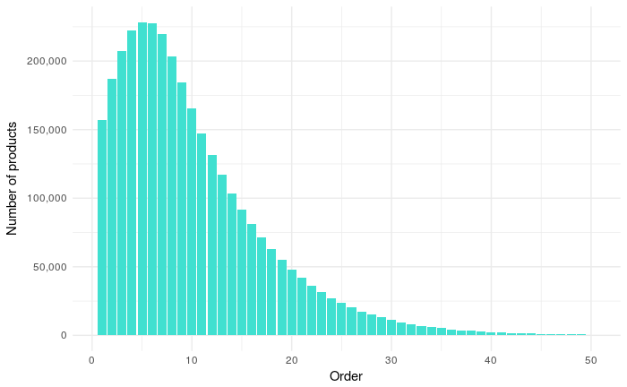

```r
products_order %>%
  filter(n_prod <= 50) %>%
  ggplot(
    aes(n_prod, n_orders)) +
  geom_bar(stat="identity", fill='turquoise') +
  scale_y_continuous(label=scales::comma) +
  xlab("Order") +
  ylab("Number of products") +
  theme_minimal()
```

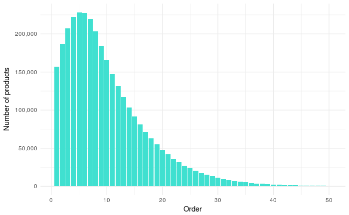

```r
order_products__prior %>%
  group_by(order_id) %>%
  summarise(n_prod = n()) %>%
  group_by(n_prod) %>%
  summarise(n_orders = n())%>%
  filter(n_prod <= 50) %>%
  collect %>%
  ggplot(aes(n_prod, n_orders)) +
    geom_bar(stat="identity", fill='turquoise') +
    scale_y_continuous(label=scales::comma) +
    xlab("Order") +
    ylab("Number of products") +
    theme_minimal()
```

- What is the most popular department?

```r
dbGetQuery(
  sc,
  "
SELECT department_id, COUNT(1) AS Frequency
FROM products_tbl
GROUP BY department_id
ORDER BY Frequency DESC
LIMIT 1
"
  )
```

| department_id | Frequency |
| --- | --- |
| 11 | 6563 |

## Whisker, magrittr

```r
library(whisker)
library(magrittr)
product_times_ordered_txt <- "
SELECT n_orders
,   COUNT(DISTINCT user_id) AS n_users
FROM (
    SELECT o.user_id
    ,   COUNT(DISTINCT op.order_id) AS n_orders
    FROM (
        SELECT order_id
        FROM order_products__prior_tbl
        WHERE product_id = {{productId}}
    ) op
    LEFT JOIN (
        SELECT  user_id
        ,   order_id
        FROM orders_tbl) o
    ON op.order_id = o.order_id
    GROUP BY o.user_id) opo
GROUP BY n_orders
ORDER BY n_orders
"
data <- list(productId = 24852)
product_times_ordered_txt %>%
  whisker.render(data) %>%
  cat
```

```
SELECT n_orders
,   COUNT(DISTINCT user_id) AS n_users
FROM (
    SELECT o.user_id
    ,   COUNT(DISTINCT op.order_id) AS n_orders
    FROM (
        SELECT order_id
        FROM order_products__prior_tbl
        WHERE product_id = 24852
    ) op
    LEFT JOIN (
        SELECT  user_id
        ,   order_id
        FROM orders_tbl) o
    ON op.order_id = o.order_id
    GROUP BY o.user_id) opo
GROUP BY n_orders
ORDER BY n_orders
```

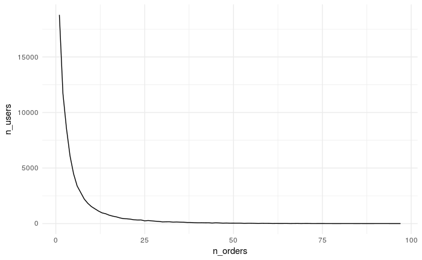

```r
product_times_ordered_txt %>%
  whisker.render(data) %>%
  dbGetQuery(sc, .) %>%
  ggplot(aes(n_orders, n_users)) +
  geom_line() +
  theme_minimal()
```

## Questions

- For given department, plot the most popular product (with templating department).

```r
dpt_prod_popularity_txt <- "
SELECT a.product_id, product_name, COUNT(1) AS popularity
FROM order_products__prior_tbl AS a
  LEFT JOIN products_tbl AS b ON a.product_id=b.product_id
WHERE department_id={{dptId}}
GROUP BY a.product_id, b.product_name
ORDER BY popularity DESC
LIMIT 10
"
data <- list(dptId=19)
dpt_prod_popularity_txt %>%
  whisker.render(data) %>%
  cat
```

```
SELECT a.product_id, product_name, COUNT(1) AS popularity
FROM order_products__prior_tbl AS a
  LEFT JOIN products_tbl AS b ON a.product_id=b.product_id
WHERE department_id=19
GROUP BY a.product_id, b.product_name
ORDER BY popularity DESC
LIMIT 10
```

```r
dpt_prod_popularity_txt %>%
  whisker.render(data) %>%
  dbGetQuery(sc, .)
```

| product_id | product_name | popularity |
| --- | --- | --- |
| 13870 | Lightly Salted Baked Snap Pea Crisps | 24950 |
| 34448 | Original Veggie Straws | 16850 |
| 31040 | Sea Salt Pita Chips | 16626 |
| 21376 | Pretzel Crisps Original Deli Style Pretzel Crackers | 15831 |
| 40709 | Sea Salt & Vinegar Potato Chips | 14800 |
| 40199 | Chocolate Chip Cookies | 14148 |
| 35561 | Organic Tortilla Chips | 13776 |
| 3599 | Baked Aged White Cheddar Rice and Corn Puffs | 13691 |
| 5194 | Organic Bunny Fruit Snacks Berry Patch | 13372 |
| 18288 | Sea Salt Potato Chips | 13086 |

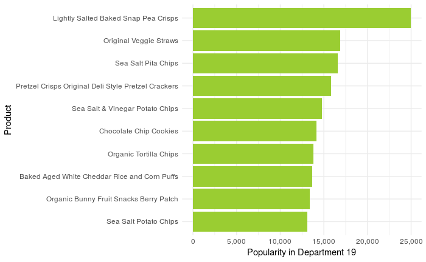

```r
dpt_prod_popularity_txt %>%
  whisker.render(data) %>%
  dbGetQuery(sc, .)%>%
  ggplot(
    aes(reorder(product_name, popularity, function(x) x),
        popularity)) +
  geom_bar(stat="identity", fill='yellowgreen') +
  coord_flip() +
  scale_y_continuous(label=scales::comma) +
  xlab("Product") +
  ylab(paste("Popularity in Department", data$dptId)) +
  theme_minimal()
```

- For given day, rank department popularity.

```r
dpt_popularity_txt <- "
SELECT department_id, COUNT(department_id) as popularity
FROM (
  SELECT product_id
  FROM order_products__train_tbl AS a INNER JOIN
       orders_tbl AS b ON a.order_id=b.order_id
  WHERE order_dow = {{dowId}}
  ) AS ab INNER JOIN
  products_tbl AS c ON ab.product_id=c.product_id
GROUP BY department_id
ORDER BY popularity DESC
"
data <- list(dowId=0)
dpt_popularity_txt %>%
  whisker.render(data) %>%
  cat
```

```
SELECT department_id, COUNT(department_id) as popularity
FROM (
  SELECT product_id
  FROM order_products__train_tbl AS a INNER JOIN
       orders_tbl AS b ON a.order_id=b.order_id
  WHERE order_dow = 0
  ) AS ab INNER JOIN
  products_tbl AS c ON ab.product_id=c.product_id
GROUP BY department_id
ORDER BY popularity DESC
```

```r
dpt_popularity_txt %>%
  whisker.render(data) %>%
  dbGetQuery(sc, .)
```

| department_id | popularity |
| --- | --- |
| 4 | 104085 |
| 16 | 50756 |
| 19 | 24853 |
| 1 | 23033 |
| 7 | 22561 |
| 13 | 18386 |
| 15 | 11656 |
| 3 | 11237 |
| 20 | 10589 |
| 9 | 9505 |

[output cut: 11 more lines]

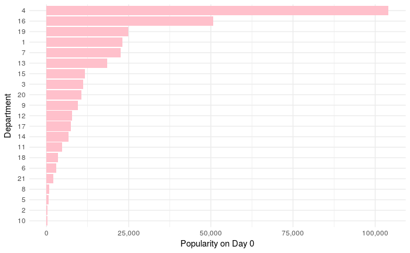

```r
dpt_popularity_txt %>%
whisker.render(data) %>%
  dbGetQuery(sc, .) %>%
  ggplot(
    aes(reorder(department_id, popularity, function(x) x),
        popularity)) +
  geom_bar(stat="identity", fill='pink') +
  coord_flip() +
  scale_y_continuous(label=scales::comma) +
  xlab("Department") +
  ylab(paste("Popularity on Day", data$dowId)) +
  theme_minimal()
```

## More on orders (Window Functions)

```r
dbGetQuery(sc,
"
SELECT days_since_prior_order
,   COUNT(1) AS N
FROM orders_tbl
GROUP BY days_since_prior_order
")
```

```r
dbGetQuery(sc,
"SELECT *
FROM orders_tbl
WHERE user_id <= 10
")
```

```r
dbGetQuery(sc,
"SELECT user_id
,   order_id
,   FIRST_VALUE(order_id)  OVER(partition by user_id ORDER BY order_number) AS first_order
FROM orders_tbl
WHERE user_id <= 10
")
```

*Product that is usually orders in numerous baskets*

```r
"
SELECT product_id
,   AVG(products_number) AS avg_products_number
FROM (
    SELECT order_id
    ,   product_id
    ,   COUNT(product_id)  OVER(partition by order_id) AS products_number
    FROM order_products__train_tbl
) pn
GROUP BY product_id
ORDER BY avg_products_number DESC
LIMIT 100
" %>%
dbGetQuery(sc, .)
```

Calcula el nombre de productes que hi ha en una cistella de la compra i ho afegeix a cada producte; llavors per cada product_id calcula el nombre mig de productes que hi ha en les cistelles en què és comprat.

*Could modify the query and add product name?*

```r
"
SELECT b.product_name, a.*
FROM (
  SELECT pn.product_id
  ,   AVG(products_number) AS avg_products_number
  FROM (
    SELECT order_id
    ,   product_id
    ,   COUNT(product_id)  OVER(partition by order_id) AS products_number
    FROM order_products__train_tbl
  ) pn
  GROUP BY product_id
  ORDER BY avg_products_number DESC
  LIMIT 100
) a LEFT JOIN products_tbl b ON a.product_id=b.product_id
" %>%
dbGetQuery(sc, .)
```

| product_name | product_id | avg_products_number |
| --- | --- | --- |
| Nutrafix Hair Reconstructor | 40370 | 76.0 |
| Pretzel Chocolate Organic | 8991 | 76.0 |
| Hydro Towel, Exfoliating | 37743 | 76.0 |
| Simtra Triple IPA | 11082 | 75.0 |
| Sea Salt 72% Cacao Dark Chocolate | 31023 | 75.0 |
| Ruination Double India Pale Ale | 2139 | 75.0 |
| Dark Belgian Beer | 42148 | 75.0 |
| Toffe + Sea Salt | 47607 | 75.0 |
| Coconut Cookies | 12851 | 72.0 |
| Cheesy Cheddar Rotini Pasta Sides | 28235 | 72.0 |

[output cut: 90 more lines]

*Product that is usually orders in small baskets*

```r
"
SELECT product_id
,   AVG(products_number) AS avg_products_number
FROM (
    SELECT order_id
    ,   product_id
    ,   COUNT(product_id)  OVER(partition by order_id) AS products_number
    FROM order_products__train_tbl
) pn
GROUP BY product_id
ORDER BY avg_products_number ASC
LIMIT 100
" %>%
dbGetQuery(sc, .)
```

- With name

```r
"
SELECT b.product_name, a.*
FROM (
  SELECT pn.product_id
  ,   AVG(products_number) AS avg_products_number
  FROM (
    SELECT order_id
    ,   product_id
    ,   COUNT(product_id)  OVER(partition by order_id) AS products_number
    FROM order_products__train_tbl
  ) pn
  GROUP BY product_id
  ORDER BY avg_products_number ASC
  LIMIT 100
) a LEFT JOIN products_tbl b ON a.product_id=b.product_id
" %>%
dbGetQuery(sc, .)
```

*For the 10 first users and all their orders find the days since first order*

- Days from first to last:

```r
dbGetQuery(sc,
"
SELECT user_id, SUM(days_since_prior_order) as days_since_first_order
FROM(
  SELECT user_id
  ,   order_id
  ,   days_since_prior_order
  ,   FIRST_VALUE(order_id)  OVER(partition by user_id ORDER BY order_number) AS first_order
  FROM orders_tbl
  WHERE user_id <= 10)
GROUP BY user_id
ORDER BY user_id
")
```

| user_id | days_since_first_order |
| --- | --- |
| 1 | 190 |
| 2 | 228 |
| 3 | 144 |
| 4 | 85 |
| 5 | 46 |
| 6 | 40 |
| 7 | 209 |
| 8 | 70 |
| 9 | 66 |
| 10 | 109 |

- Cummulative sum until each order:

```r
dbGetQuery(sc,
"
SELECT user_id
,   order_id
,   order_number
,   days_since_prior_order
,   IF(days_since_first_order IS NULL, 0, days_since_first_order) as days_since_first_order
FROM(
SELECT user_id
,   order_id
,   order_number
,   days_since_prior_order
,   SUM(days_since_prior_order) OVER (partition by user_id ORDER BY order_number) AS days_since_first_order
FROM orders_tbl
WHERE user_id <= 10
) a
ORDER BY user_id
")
```

| user_id | order_id | order_number | days_since_prior_order | days_since_first_order |
| --- | --- | --- | --- | --- |
| 1 | 2539329 | 1 | NaN | 0 |
| 1 | 2398795 | 2 | 15 | 15 |
| 1 | 473747 | 3 | 21 | 36 |
| 1 | 2254736 | 4 | 29 | 65 |
| 1 | 431534 | 5 | 28 | 93 |
| 1 | 3367565 | 6 | 19 | 112 |
| 1 | 550135 | 7 | 20 | 132 |
| 1 | 3108588 | 8 | 14 | 146 |
| 1 | 2295261 | 9 | 0 | 146 |
| 1 | 2550362 | 10 | 30 | 176 |

[output cut: 79 more lines]

```r
"
SELECT user_id
,   order_id
,   order_number
,   days_since_prior_order
,   COALESCE(
      SUM(days_since_prior_order) OVER
      (PARTITION by user_id ORDER BY order_number),
      0) AS days_since_first_order
FROM orders_tbl
WHERE user_id <= 10
ORDER BY user_id
,   order_number
" %>%
  dbGetQuery(sql_con,.)
```

```
Error in rsqlite_send_query(conn@ptr, statement) :
  near "OVER": syntax error
```

```r
orders %>%
  filter(user_id <= 10) %>%
  select(user_id, order_number, days_since_prior_order) %>%
  arrange(user_id, order_number) %>%
  mutate(days_since_first_order = cumsum(days_since_prior_order)) %>%
  mutate(days_since_first_order=ifelse(is.null(days_since_prior_order), 0, days_since_first_order))
```

| user_id | order_number | days_since_prior_order | days_since_first_order |
| --- | --- | --- | --- |
| 1 | 1 | NaN | 0 |
| 1 | 2 | 15 | 15 |
| 1 | 3 | 21 | 36 |
| 1 | 4 | 29 | 65 |
| 1 | 5 | 28 | 93 |
| 1 | 6 | 19 | 112 |
| 1 | 7 | 20 | 132 |
| 1 | 8 | 14 | 146 |
| 1 | 9 | 0 | 146 |
| 1 | 10 | 30 | 176 |

[output cut: 79 more lines]